# Amazon Alexa Reviews

Varsha Agarwalla

January 30, 2019

## Alexa! Can you please help me here?

### Introduction

Few months back, I bought Alexa dot because it was cheap and compact in size. My sister saw it and asked me to get her one too. However, she didn’t want the exact same thing. So I looked at Amazon and was going through the reviews. There were so many varities. Each had more than 1000 reviews and had mixed reactions which made it difficult for me to decide on one good product. While googling, I came across this dataset in Kaggle.

Dataset overview- It consists of a nearly 3000 Amazon customer reviews (input text), star ratings, date of review, variant and feedback of various amazon Alexa products like Alexa Echo, Echo dots, Alexa Firesticks etc.

I thought, being a Data Scientist, I would learn how to train machine for sentiment analysis.

### Packages Required

```r
library(tidyverse)  #to visualize, transform, input, tidy and join data
library(readr)      #to input data from tsv
library(dplyr)      #data wrangling
library(kableExtra) #to create HTML Table
library(DT)         #to preview the data sets
library(lubridate)  #to apply the date functions
library(tm)         #to text mine
library(wordcloud)  #to build word cloud
library(tidytext)   #to text mine
```

### Exloratory Data Analysis:

Data overview-

|  | rating | date | variation | verified_reviews | feedback |
| --- | --- | --- | --- | --- | --- |
| 1 | 5 | 31-Jul-18 | Charcoal Fabric | Love my Echo! | 1 |
| 2 | 5 | 31-Jul-18 | Charcoal Fabric | Loved it! | 1 |
| 3 | 4 | 31-Jul-18 | Walnut Finish | Sometimes while playing a game, you can answer a question correctly but Alexa says you got it wrong and answers the same as you. I like being able to turn lights on and off while away from home. | 1 |
| 4 | 5 | 31-Jul-18 | Charcoal Fabric | I have had a lot of fun with this thing. My 4 yr old learns about dinosaurs, i control the lights and play games like categories. Has nice sound when playing music as well. | 1 |
| 5 | 5 | 31-Jul-18 | Charcoal Fabric | Music | 1 |
| 6 | 5 | 31-Jul-18 | Heather Gray Fabric | I received the echo as a gift. I needed another Bluetooth or something to play music easily accessible, and found this smart speaker. Can’t wait to see what else it can do. | 1 |
| 7 | 3 | 31-Jul-18 | Sandstone Fabric | Without having a cellphone, I cannot use many of her features. I have an iPad but do not see that of any use. It IS a great alarm. If u r almost deaf, you can hear her alarm in the bedroom from out in… | 1 |
| 8 | 5 | 31-Jul-18 | Charcoal Fabric | I think this is the 5th one I've purchased. I'm working on getting one in every room of my house. I really like what features they offer specifily playing music on all Echos and controlling the lights… | 1 |
| 9 | 5 | 30-Jul-18 | Heather Gray Fabric | looks great | 1 |
| 10 | 5 | 30-Jul-18 | Heather Gray Fabric | Love it! I’ve listened to songs I haven’t heard since childhood! I get the news, weather, information! It’s great! | 1 |

[output cut: 10 more lines]

1. The dataset has reviews from 3150 alexa users.
2. The different alexa products that are reviewed -

```r
alexa %>%
  group_by(variation) %>%
  count() %>%
  arrange(desc(n))
```

```
## # A tibble: 16 x 2
## # Groups:   variation [16]
##    variation                        n
##    <chr>                        <int>
##  1 Black  Dot                     516
##  2 Charcoal Fabric                430
##  3 Configuration: Fire TV Stick   350
##  4 Black  Plus                    270
##  5 Black  Show                    265
##  6 Black                          261
##  7 Black  Spot                    241
##  8 White  Dot                     184
##  9 Heather Gray Fabric            157
## 10 White  Spot                    109
## 11 White                           91
## 12 Sandstone Fabric                90
## 13 White  Show                     85
## 14 White  Plus                     78
## 15 Oak Finish                      14
## 16 Walnut Finish                    9
```

Black Dot has maximum number of reviews, and I bought it. Yay!

3. The reviews were collected across three months of 2018.

```r
alexa$date <- as.Date(alexa$date, "%d-%b-%y")

alexa %>%
  group_by(month(date)) %>%
  count()
```

```
## # A tibble: 3 x 2
## # Groups:   month(date) [3]
##   `month(date)`     n
##           <dbl> <int>
## 1             5    82
## 2             6   155
## 3             7  2913
```

4. The products obtained reviews and rating(ranging from 1-5) according to user’s liking.

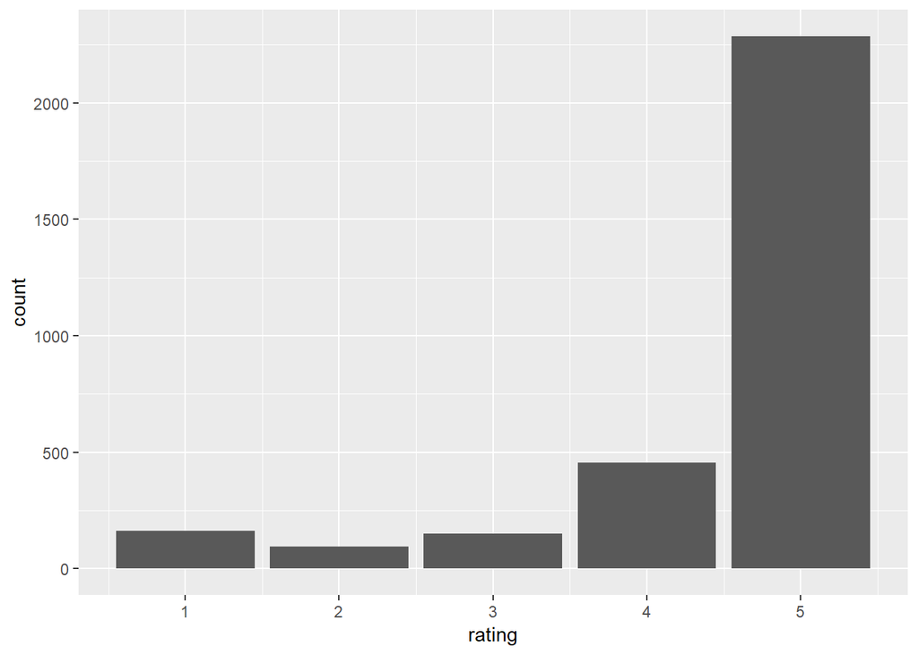

```r
ggplot(alexa , aes(rating)) +
  geom_bar()
```

According to this graph, it seems more than 70% of users liked the products and have rated them as 5

However, I feel rating is baised. People tend to feel more than what they show by their rating. Let’s look at few of the reviews from people who rated the products as **2**-

```r
alexa_reviews <- alexa %>%
  filter(rating == 2) %>%
  select(verified_reviews)

alexa_head <- head(alexa_reviews, n = 20)
datatable(alexa_head, caption = "Some of the reviews of people who rated the products as 2")
```

|  | verified_reviews |
| --- | --- |
| 1 | It's like Siri, in fact, Siri answers more accurately then Alexa. I don't see a real need for it in my household, though it was a good bargain on prime day deals. |
| 2 | Sound is terrible if u want good music too get a bose |
| 3 | Sad joke. Worthless. |
| 4 | Really disappointed Alexa has to be plug-in to wall socket all the time. My fault for not checking this, but made the assumption that a company has technologically advanced as Amazon would sell this p… |
| 5 | It's got great sound and bass but it doesn't work all of the time. Its still hot or miss when it recognizes things |
| 6 | I am not super impressed with Alexa. When my Prime lapsed, she wouldn't play anything. She isn't smart enough to differentiate among spotify accounts so we can't use it for that either. She randomly s… |
| 7 | Too difficult to set up. It keeps timing out before you can enter the password |
| 8 | Doesn't always respond when spoken to with promp word. I thought it would connect to my echo upstairs and use it like an intercom haven't been able to do that. |
| 9 | Poor quality. Gave it away. |
| 10 | Initially, this echo dot worked very well. Over time, the dot stopped responding to 'alexa' unless you were within one foot of it yelling. The other echos/echo dots in other rooms would respond withou… |

[output cut: 10 more lines]

**“Poor quality”**, **“Too difficult to set-up”** and **“Worthless”** are few of the phrases that I observe. If I had this terrible experience, I would have rated the product 1 instead.

So, let’s explore the reviews in depth-

```r
alexa_reviews <- VectorSource(alexa$verified_reviews)
alexa_corpus <- VCorpus(alexa_reviews)
clean_corpus <- function(corpus) {
  #remove puntuation
  corpus <- tm_map(corpus, removePunctuation)
  #transform to lower case
  corpus <- tm_map(corpus, content_transformer(tolower))
  #add stopwords
  corpus <- tm_map(corpus, removeWords, stopwords("en"))
  #strip whitespace
  corpus <- tm_map(corpus, stripWhitespace)
  return(corpus)
}

alexa_clean <- clean_corpus(alexa_corpus)
alexa_tdm  <- TermDocumentMatrix(alexa_clean)
alexa_m <- as.matrix(alexa_tdm)
```

Let’s look at the top 10 most used words in the reviews-

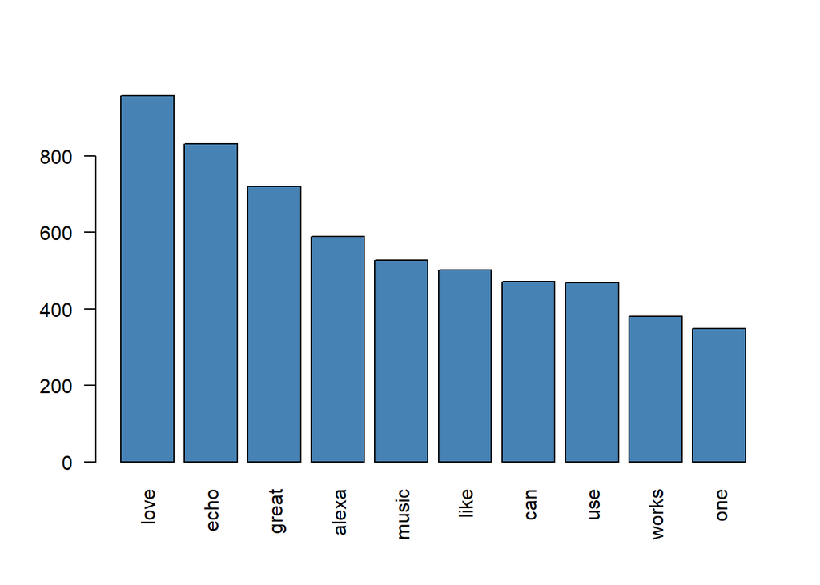

```r
term_frequency <- rowSums(alexa_m) %>%
  sort(decreasing = TRUE)

barplot(term_frequency[1:10], col = "steelblue", las = 2)
```

Words like *echo*, *music*, *alexa* have appeared more number of times, which is pretty obvious.

Let’s look at few more words-

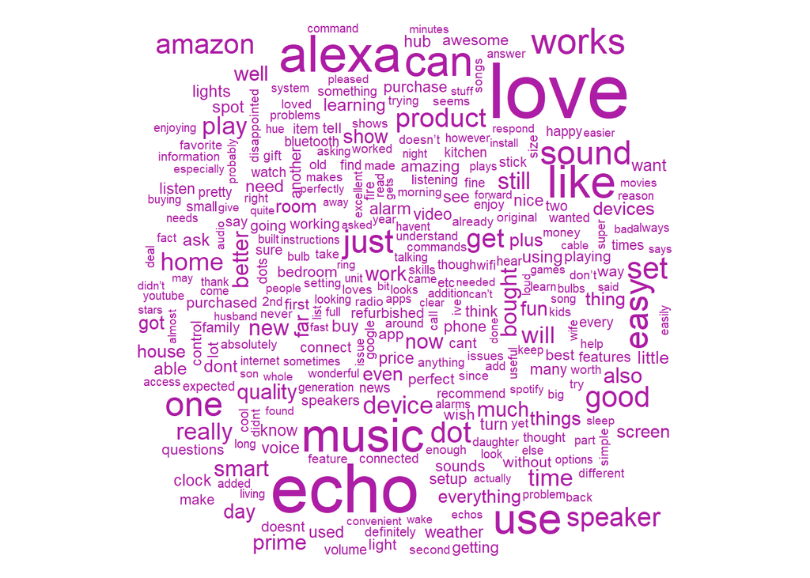

```r
word_freqs <- data.frame(term = names(term_frequency),
                         num = term_frequency)
wordcloud(word_freqs$term, word_freqs$num, max.words = 300,
          colors = "#AD1DA5")
```

we observe words like echo, amazon, product, music more frequenty. Few not-so-good words are also observed. Let’s remove the obvious words and look deep.

```r
clean_corpus <- function(corpus) {
  #remove puntuation
  corpus <- tm_map(corpus, removePunctuation)
  #transform to lower case
  corpus <- tm_map(corpus, content_transformer(tolower))
  #add stopwords
  corpus <- tm_map(corpus, removeWords, c(stopwords("en"),"amazon","echo",
                                          "music","speaker","dot","device",
                                          "devices","product","alexa","can",
                                          "one","use","just","get","set","still","bought","will"))
  #strip whitespace
  corpus <- tm_map(corpus, stripWhitespace)
  return(corpus)
}

alexa_clean <- clean_corpus(alexa_corpus)
alexa_tdm  <- TermDocumentMatrix(alexa_clean)
alexa_m <- as.matrix(alexa_tdm)
term_frequency <- rowSums(alexa_m) %>%
  sort(decreasing = TRUE)
```

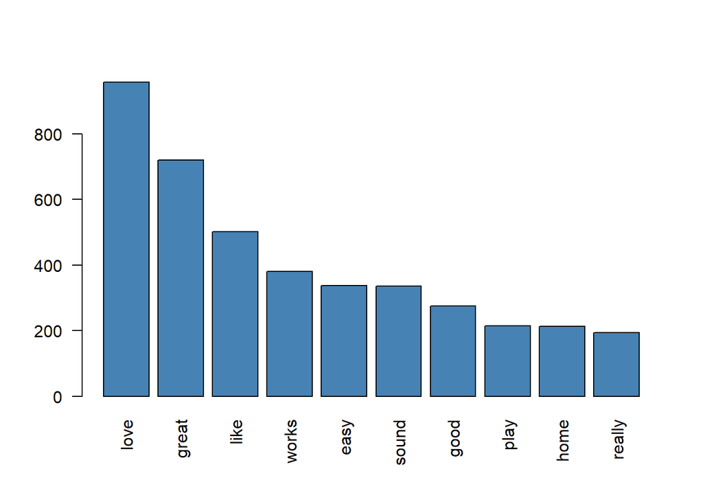

```r
barplot(term_frequency[1:10], col = "steelblue", las = 2)
```

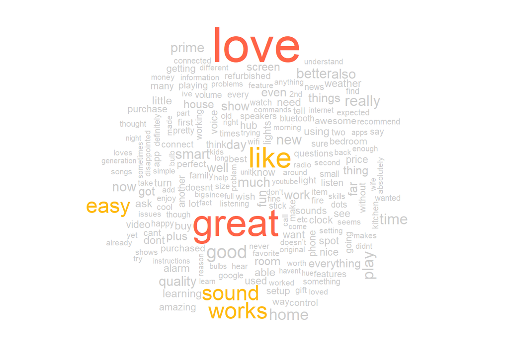

```r
word_freqs <- data.frame(term = names(term_frequency),
                         num = term_frequency)

wordcloud(word_freqs$term, word_freqs$num, max.words = 200,
          colors = c("grey80","darkgoldenrod1","tomato" ))
```

Here, we see lot more words and actually to be honest, they are quite mixed. Let’s try to seggregate the words into positive and negative. We can guage some sentiments behind those reviews

```r
check <- alexa %>%  unnest_tokens(word, verified_reviews)

check1 <- check %>%
  group_by(word) %>%
  mutate(freq = n()) %>%
  select(rating, variation, feedback, word, freq)

checked <- check1 %>%  inner_join(get_sentiments("bing"), by = "word")
```

I would look at the positive(in green) and negative(in red) reviews received-

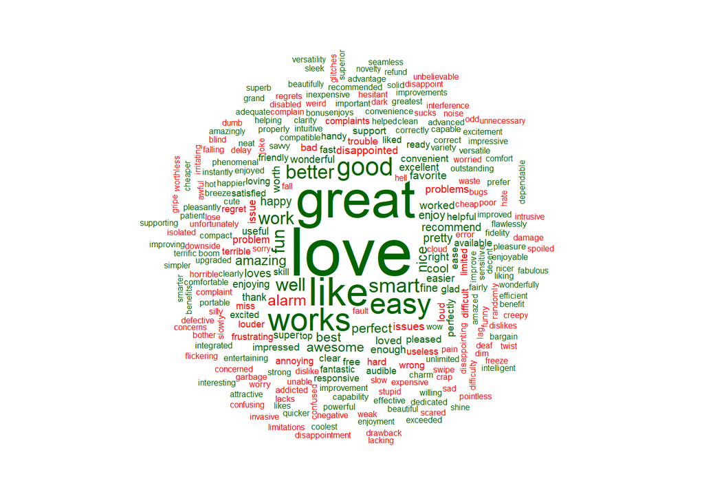

```r
what <- checked %>%
  count(word, sentiment) %>%
  mutate(color = ifelse(sentiment == "positive", "darkgreen", "red"))

wordcloud(what$word, what$n, random.order = FALSE, colors = what$color, ordered.colors = TRUE)
```

Wow! This gives a much better overview. We observe that positive words like **love** and **great** are dominating. However, there are also negatives ones like- **disappointing**, **frustrating**, **disabled**. Woah! This is not good.

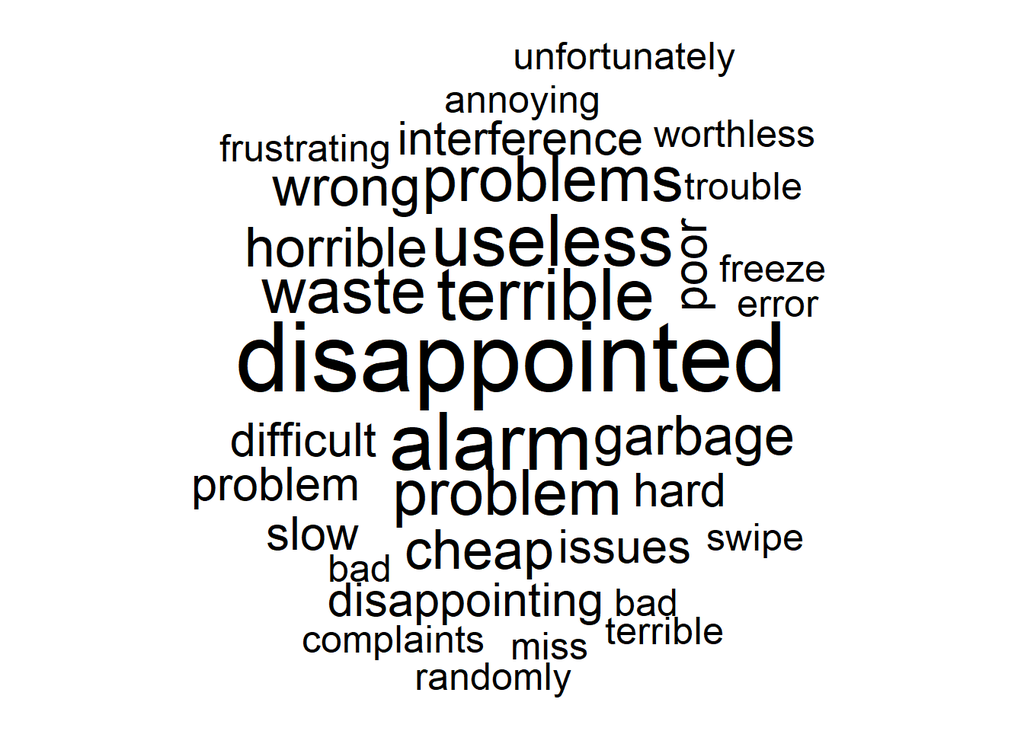

```r
below_rated <- checked %>%
  filter(rating <= 2) %>%
  count(word, rating, sentiment) %>%
  filter(sentiment == 'negative')

wordcloud(below_rated$word, below_rated$n, max.words = 100, random.order = FALSE)
```

This segregration of words into positive and negative does help me make sense of public rating.

Let me look at the ratio of positive and negative words used per product.

checking the positive/negative ratio across the different alexa products, I find that **White Show** is appreciated the most whereas **Black Spot** isn’t taken well.

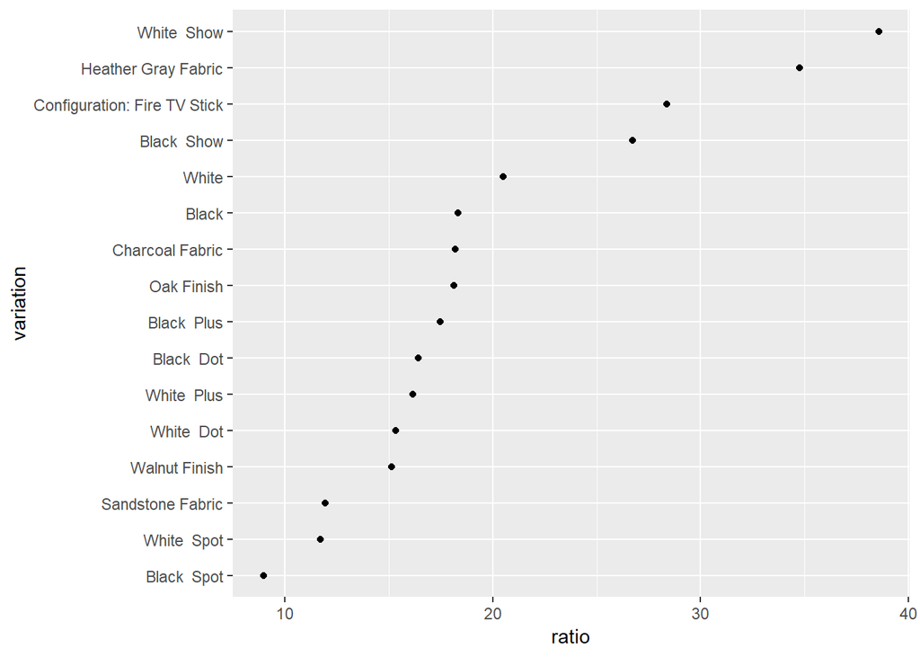

```r
checked %>%
  group_by(variation, sentiment) %>%
  summarize(freq = mean(freq)) %>%
  spread(sentiment, freq) %>%
  ungroup() %>%
  mutate(ratio = positive/negative,
         variation = reorder(variation, ratio)) %>%
  ggplot(aes(variation, ratio)) +
  geom_point() +
  coord_flip()
```

Pppft! I can go ahead and buy White Show.

### Conclusion

Examining text data allows us to illustrate many real complexities of data engineering, and also helps us to understand better a very important type of data. Medical records, consumer complaint logs, etc are still recorded as text, and exploiting this vast amount of data requires converting them into a meaningful form.

This dataset gave me a brief understanding of how to text mine the data and understand the underlying sentiments.

**Methodology**

1. I performed text mining on the reviews. Reviews were broken down into individual words. Common english words were removed so that other not-so-frequent words would come into the picture.
2. Once I identified a pattern, I used sentiments lexicon to further classify the words into different type of sentiments to understand customers better.

**Implication**

This analysis can be used to further deep-dive into words and sentiments underneath those words. It will not only help in understanding customers better but we can use it to further improve the overall product quality.

**Limitation**

Text mining is one important data processing step. By this analysis, I tried to make some sense from the data but I would like to explore more in-detail. I would like to see what happens when I look at phrases instead of individual words. I would also like to create a model so that I can predict emotions and learn about products thereby contributing in the real-world.